# directionality analysis

Rubén Rellán Álvarez

July 21, 2015

This is an example of directionality analysis

We will start by loading all the packages that we will be using. Use `install.package()` if you don´t have these packages installed already.

We have first run the directionality analysis in GLO-RIA. A root-data-dir.csv file is created and the first thing we have to do is load the data into R. Please notice that we have created before an R project file in the folder where all the data is stored.

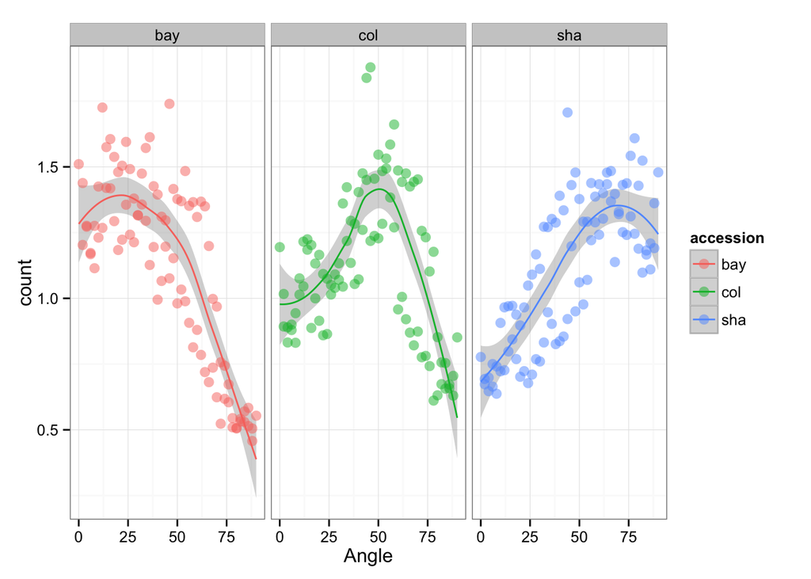

```r
dir <- read.csv("root-data-dir.csv")

# we take the absolute values of the angles

dir$angle <- abs(dir$angle)

# we then create new variables using the `separate` function

dir_tidy <- dir %>%
        separate(image, into = c("experiment", "das", "accession", "plant", "aq"), sep = "-") %>%
        dplyr::select(accession, angle, count) # this is to get rid of the extra variables

# I will save this new file:

write.csv(dir_tidy, file = "dir_tidy.csv")

# we plot the directionality distributions

ggplot(dir_tidy, aes(x = angle, y = count, colour = accession)) +
       facet_grid(~ accession) +
        geom_smooth()+
        geom_point(size = 3, alpha = 0.5) +
        labs(x = "Angle", y = "count") +
              theme(panel.grid.major = element_blank(), # this removes the grid lines
              panel.grid.minor = element_blank()) + # this removes the grid lines
        theme_bw()
```

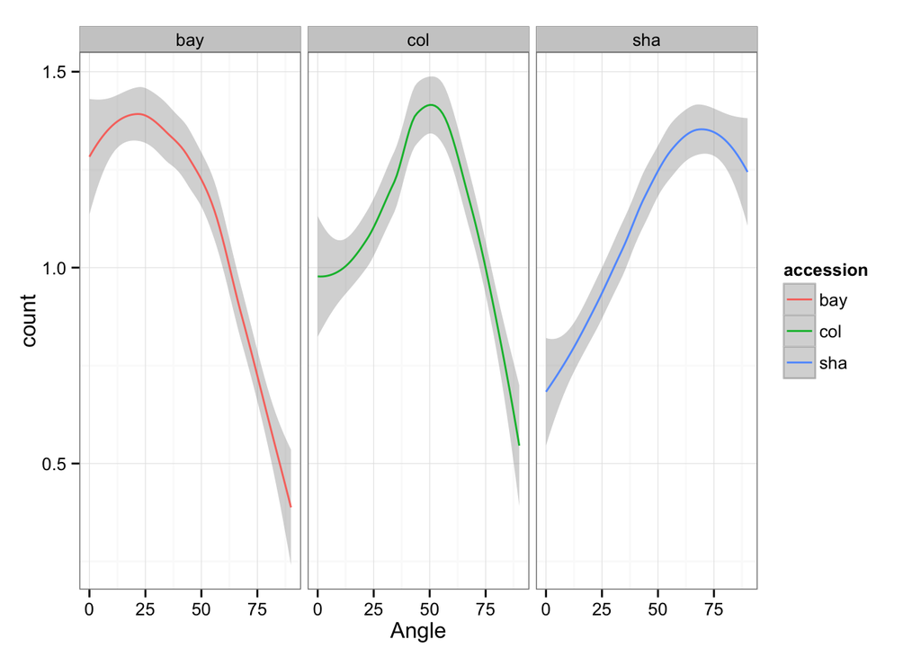

```r
# we could plot just the lm curve

ggplot(dir_tidy, aes(x = angle, y = count, colour = accession)) +
       facet_grid(~ accession) +
        geom_smooth() +
        labs(x = "Angle", y = "count") +
              theme(panel.grid.major = element_blank(),
              panel.grid.minor = element_blank()) +
        theme_bw()
```

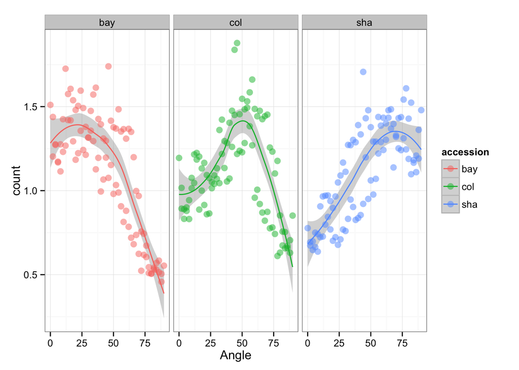

```r
# If you want to save the plot, I recomend using the ggsave function, and save it as a PDF.

ggplot(dir_tidy, aes(x = angle, y = count, colour = accession)) +
       facet_grid(~ accession) +
        geom_smooth()+
        geom_point(size = 3, alpha = 0.5) +
        labs(x = "Angle", y = "count") +
              theme(panel.grid.major = element_blank(),
              panel.grid.minor = element_blank()) +
        theme_bw()
```

```r
        ggsave("directionality.pdf", height = 8, width = 12, units =
                       "cm",useDingbats = FALSE)
```

We then may want to test if the directionality distributions between two treatments or genotypes is different. For this we use the Kolmogorov-Smirnoff test. The function to call this test is `ks.test` and is included in R base functions. The function will compare two vectors, in our case the count values for each genotype or treatment. The format of the file will then have to be slightly different than the ones we created. We want to have a column with the angle values and the following values will be the counts for each genotype/treatment. In our case we would have:

angle | count-bay | count-col | count-sha |

There should be an easier way to do this transformation using R, but I am getting some errors so I do it manually in excel and then load the new file.

```r
wide_dir <- read.csv("dir_tidy_wide.csv")

ks.test(wide_dir$count_bay, wide_dir$count_col) # are bay and col different?
```

```
##
##  Two-sample Kolmogorov-Smirnov test
##
## data:  wide_dir$count_bay and wide_dir$count_col
## D = 0.17778, p-value = 0.1164
## alternative hypothesis: two-sided
```

```r
ks.test(wide_dir$count_bay, wide_dir$count_sha) # are bay and col different?
```

```
##
##  Two-sample Kolmogorov-Smirnov test
##
## data:  wide_dir$count_bay and wide_dir$count_sha
## D = 0.18889, p-value = 0.08052
## alternative hypothesis: two-sided
```

```r
ks.test(wide_dir$count_col, wide_dir$count_sha) # are sha and col different?
```

```
##
##  Two-sample Kolmogorov-Smirnov test
##
## data:  wide_dir$count_col and wide_dir$count_sha
## D = 0.12222, p-value = 0.5145
## alternative hypothesis: two-sided
```

As you can see from the results the p-values are quite high. This is due to the fact that we only have one sample per accession.